[figure not shown]

# Face Mask Prediction using U-Net

Task is to predict the mask around the face in a given image.

# Instructions

- Some part of the code is already done for you
- You need to execute all the cells
- You need to add the code where ever you see `"#### Add your code here ####"`
- Marks are mentioned along with the cells

## Dataset

Faces in images marked with bounding boxes. Have around 409 images with around 1000 faces manually tagged via bounding box.

- Data file name: images.npy

### Mount Google drive if you are using google colab

- We recommend using Google Colab as you can face memory issues and longer runtimes while running on local

```python
from google.colab import drive
drive.mount('/content/drive')
```

```python
# Initialize the random number generator
import random
random.seed(0)
```

### Load the "images.npy" file (2 marks)

- This file contains images with details of bounding boxes

```python
import numpy as np
data = np.load(file='/content/drive/My Drive/Colab Notebooks/images.npy',allow_pickle=True)
```

```python
type(data)
```

```
numpy.ndarray
```

```python
data.shape
```

```
(409, 2)
```

### Check one sample from the loaded "images.npy" file (2 marks)

- Hint: print data[10][1]

```python
print(data[10][0])
```

```
[[[ 15  15  15]
  [ 14  14  14]
  [ 14  14  14]
  ...
  [218 218 218]
  [221 221 221]
  [224 224 224]]

 [[ 16  16  16]
  [ 15  15  15]
  [ 13  13  13]
  ...
  [216 216 216]
  [225 225 225]
  [214 214 214]]

 [[ 16  16  16]
  [ 14  14  14]
  [ 12  12  12]
  ...
  [215 215 215]
  [215 215 215]
  [225 225 225]]

 ...

 [[  7   7   7]
  [  9   9   9]
  [  3   3   3]
  ...
  [ 55  57  56]
  [ 57  59  58]
  [ 57  59  58]]

 [[  8   8   8]
  [ 10  10  10]
  [  4   4   4]
  ...
  [ 56  58  57]
  [ 57  59  58]
  [ 57  59  58]]

 [[  9   9   9]
  [ 12  12  12]
  [  5   5   5]
  ...
  [ 56  58  57]
  [ 56  58  57]
  [ 57  59  58]]]
```

```python
print(data[10][1])
```

```
[{'label': ['Face'], 'notes': '', 'points': [{'x': 0.3484375, 'y': 0.26666666666666666}, {'x': 0.6640625, 'y': 0.8444444444444444}], 'imageWidth': 640, 'imageHeight': 360}]
```

```python
# Image size
print(data[10][0].shape)

# Face Mask details
print(len(data[10][1]))
```

```
(360, 640, 3)
1
```

### Set image dimensions (1 mark)

- Initialize image height, image width with value: 224

```python
IMAGE_HEIGHT = 224
IMAGE_WIDTH = 224
```

### Create features and labels

- Here feature is the image
- The label is the mask
- Images will be stored in "X" array
- Masks will be stored in "masks" array

```python
import cv2
from tensorflow.keras.applications.mobilenet import preprocess_input

# Have removed pre-processing from here and kept it in ImageDataGenerator
masks = np.zeros((int(data.shape[0]), IMAGE_HEIGHT, IMAGE_WIDTH),dtype=np.uint8)
X = np.zeros((int(data.shape[0]), IMAGE_HEIGHT, IMAGE_WIDTH, 3),dtype=np.uint8)
for index in range(data.shape[0]):
    img = data[index][0]
    img = cv2.resize(img, dsize=(IMAGE_HEIGHT, IMAGE_WIDTH), interpolation=cv2.INTER_CUBIC)
    try:
      img = img[:, :, :3]
    except:
      continue
    X[index] = img
    for i in data[index][1]:
        x1 = int(i["points"][0]['x'] * IMAGE_WIDTH)
        x2 = int(i["points"][1]['x'] * IMAGE_WIDTH)
        y1 = int(i["points"][0]['y'] * IMAGE_HEIGHT)
        y2 = int(i["points"][1]['y'] * IMAGE_HEIGHT)
        masks[index][y1:y2, x1:x2] = 1
```

### Split the data into training and testing (2 marks)

- 400 images in training
- 9 images in testing data

Data split

```python
# Instead of keeping all 400 in training data, have split full set into train, validation and test dataset
X_train, X_val, X_test = X[0:370,:,:,:], X[370:400,:,:,:], X[400:,:,:,:]

# Reshaping the mask data because Img data generator accepts in below format
y_train, y_val, y_test = masks[0:370,:,:].reshape(370,224,224,1), masks[370:400,:,:].reshape(30,224,224,1), masks[400:,:,:].reshape(9,224,224,1)
```

```python
from keras.preprocessing.image import ImageDataGenerator
```

```python
# Image date generator setup
image_datagen = ImageDataGenerator(rotation_range=15, width_shift_range=0.15, height_shift_range=0.15,shear_range=0.15, zoom_range=0.2, fill_mode='nearest', horizontal_flip=True,preprocessing_function=preprocess_input, dtype=np.float64)
mask_datagen = ImageDataGenerator(rotation_range=15, width_shift_range=0.15, height_shift_range=0.15,shear_range=0.15, zoom_range=0.2,  fill_mode='nearest', horizontal_flip=True, dtype=np.uint8)
seed = 1
image_datagen.fit(X_train, augment=True, seed=seed)
mask_datagen.fit(y_train, augment=True, seed=seed)

image_generator = image_datagen.flow(X_train,seed=seed,batch_size=1)
mask_generator = mask_datagen.flow(y_train,seed=seed,batch_size=1)

# combine generators into one which yields image and masks
train_generator = zip(image_generator, mask_generator)

# Validation set
#preprocessing_function=preprocess_input,
image_datagen_val = ImageDataGenerator(preprocessing_function=preprocess_input,dtype=np.float64)
mask_datagen_val = ImageDataGenerator(dtype=np.uint8)
seed = 1
image_datagen_val.fit(X_val, augment=True, seed=seed)
mask_datagen_val.fit(y_val, augment=True, seed=seed)

image_generator_val = image_datagen_val.flow(X_val,batch_size=1,seed=seed)
mask_generator_val = mask_datagen_val.flow(y_val,batch_size=1,seed=seed)

# combine generators into one which yields image and masks
val_generator = zip(image_generator_val, mask_generator_val)
```

### Print a sample training image, image array and its mask (2 marks)

Print the image and image array

```python
import matplotlib.pyplot as plt
```

```python
#  Training data generated by Image generator
i,m=image_generator[50][0],mask_generator[50].reshape(224,224)
```

```
Clipping input data to the valid range for imshow with RGB data ([0..1] for floats or [0..255] for integers).
```

[figure not shown]

```python
# Image by Generator
plt.imshow(i)
```

```python
print(i)
```

```
[[[-0.66184974 -0.67014056 -0.70980394]
  [-0.6342542  -0.65634274 -0.70980394]
  [-0.61283714 -0.642545   -0.7221609 ]
  ...
  [ 0.46013653 -0.00598592 -0.316334  ]
  [ 0.4478562  -0.01724297 -0.3286144 ]
  [ 0.43557584 -0.02849996 -0.34089476]]

 [[-0.66020876 -0.6680519  -0.70980394]
  [-0.6385314  -0.65848136 -0.70980394]
  [-0.616045   -0.6446836  -0.7200223 ]
  ...
  [ 0.3800956  -0.08264947 -0.4003262 ]
  [ 0.36986208 -0.09288305 -0.4115832 ]
  [ 0.35962832 -0.10311675 -0.42284012]]

 [[-0.6570009  -0.66484404 -0.70980394]
  [-0.64280856 -0.66062    -0.70980394]
  [-0.6192529  -0.6468222  -0.7178837 ]
  ...
  [ 0.4889542   0.01589906 -0.30566955]
  [ 0.53295887  0.05683351 -0.26473504]
  [ 0.57696354  0.09776819 -0.22380048]]

 ...

 [[-0.40240586 -0.3706584  -0.5661983 ]
  [-0.3363986  -0.2989232  -0.53172284]
  [-0.33324647 -0.2940308  -0.5345512 ]
  ...
  [ 0.23956954 -0.4333176  -0.84118176]
  [ 0.43864882 -0.3091377  -0.85703516]
  [ 0.5714271  -0.18895733 -0.77094924]]

 [[-0.41540182 -0.38029855 -0.5687643 ]
  [-0.34154212 -0.30513602 -0.54161453]
  [-0.33443135 -0.29521567 -0.54548585]
  ...
  [ 0.2064215  -0.4525649  -0.834766  ]
  [ 0.4172629  -0.328385   -0.87093604]
  [ 0.5552405  -0.2042051  -0.78125054]]

 [[-0.41502917 -0.37870538 -0.5628288 ]
  [-0.3451407  -0.3107345  -0.53796923]
  [-0.34518564 -0.3088345  -0.5485537 ]
  ...
  [ 0.17327332 -0.4718122  -0.8283502 ]
  [ 0.38713872 -0.3476323  -0.86974347]
  [ 0.5338546  -0.22345239 -0.79515135]]]
```

Print the mask

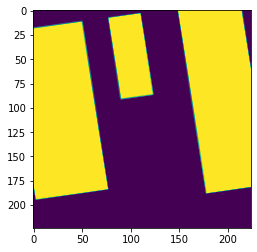

```python
#  Mask generated by Image generator
plt.imshow(m)
```

## Create the model (5 marks)

- Add MobileNet as model with below parameter values
  - input_shape: IMAGE_HEIGHT, IMAGE_WIDTH, 3
  - include_top: False
  - alpha: 1.0
  - weights: "imagenet"
- Add UNET architecture layers
  - This is the trickiest part of the project, you need to research and implement it correctly

```python
from tensorflow.keras.applications.mobilenet import MobileNet
from tensorflow.keras.layers import Reshape, UpSampling2D, Concatenate, Conv2D,Conv2DTranspose,BatchNormalization,Dropout,SeparableConv2D,SpatialDropout2D
from tensorflow.keras.models import Model

def create_model(full_model_train=False,conc_trainable=False):
    model = MobileNet(input_shape=(IMAGE_HEIGHT, IMAGE_WIDTH, 3), include_top=False, alpha=1.0, weights="imagenet")

    conv_con_list=['conv_pw_1_relu','conv_pw_3_relu','conv_pw_5_relu','conv_pw_8_relu','conv_pw_11_relu','conv_pw_12_relu','conv_pw_13_relu']

    for layer in model.layers:
      if conc_trainable and layer in conv_con_list:
        layer.trainable = conc_trainable
      elif full_model_train:
        layer.trainable = full_model_train
      else:
        layer.trainable = False

    conv1 = model.get_layer("conv_pw_1_relu").output
    conv3 = model.get_layer("conv_pw_3_relu").output
    conv5 = model.get_layer("conv_pw_5_relu").output
    conv8 = model.get_layer("conv_pw_8_relu").output
    conv11 = model.get_layer("conv_pw_11_relu").output
    conv12 = model.get_layer("conv_pw_12_relu").output
    conv13 = model.get_layer("conv_pw_13_relu").output

    deconv1_con= Concatenate()([conv13, conv12])
    deconv1_bn= BatchNormalization(axis=-1, momentum=0.99)(deconv1_con)
    deconv1_dout= SpatialDropout2D(0.3)(deconv1_bn)

    deconv2 = Conv2DTranspose(filters = 1024, kernel_size= (3, 3), padding='same', strides=(2,2), activation='relu')(deconv1_dout)
    deconv2_con= Concatenate()([deconv2, conv11, conv8])
    deconv2_bn= BatchNormalization(axis=-1, momentum=0.99)(deconv2_con)
    deconv2_dout= SpatialDropout2D(0.3)(deconv2_bn)

    conv2_1= Conv2D(filters=512, kernel_size= (3, 3), activation='relu', padding='same')(deconv2_dout)
    conv2_1_bn= BatchNormalization(axis=-1, momentum=0.99)(conv2_1)

    conv2_2= SeparableConv2D(filters=512, kernel_size= (3, 3),dilation_rate=(2, 2), depth_multiplier=1, activation="relu", padding="same")(conv2_1_bn)
    conv2_2_bn= BatchNormalization(axis=-1, momentum=0.99)(conv2_2)

    deconv3 = Conv2DTranspose(filters = 512, kernel_size= (3, 3), strides=(2,2),  padding="same", activation='relu')(conv2_2_bn)
    deconv3_con= Concatenate()([deconv3, conv5])
    deconv3_bn= BatchNormalization(axis=-1, momentum=0.99)(deconv3_con)
    deconv3_dout= SpatialDropout2D(0.3)(deconv3_bn)

    conv3_1= Conv2D(filters=256, kernel_size= (3, 3), activation='relu', padding='same')(deconv3_dout)
    conv3_1_bn= BatchNormalization(axis=-1, momentum=0.99)(conv3_1)

    conv3_2= SeparableConv2D(filters=256, kernel_size= (3, 3),dilation_rate=(2, 2), depth_multiplier=1, activation="relu", padding="same")(conv3_1_bn)
    conv3_2_bn= BatchNormalization(axis=-1, momentum=0.99)(conv3_2)

    deconv4= Conv2DTranspose(filters = 256, kernel_size= (3, 3), strides=(2,2),  padding="same", activation='relu')(conv3_2_bn)
    deconv4_con= Concatenate()([deconv4, conv3])
    deconv4_bn= BatchNormalization(axis=-1, momentum=0.99)(deconv4_con)
    deconv4_dout= SpatialDropout2D(0.3)(deconv4_bn)

    conv4_1= Conv2D(filters=256, kernel_size= (3, 3), activation='relu', padding='same')(deconv4_dout)
    conv4_1_bn= BatchNormalization(axis=-1, momentum=0.99)(conv4_1)

    conv4_2= SeparableConv2D(filters=128, kernel_size= (3, 3),dilation_rate=(2, 2), depth_multiplier=1, activation="relu", padding="same")(conv4_1_bn)
    conv4_2_bn= BatchNormalization(axis=-1, momentum=0.99)(conv4_2)

    deconv5= Conv2DTranspose(filters = 128, kernel_size= (3, 3), strides=(2,2), padding="same", activation='relu')(conv4_2_bn)
    deconv5_con= Concatenate()([deconv5, conv1])
    deconv5_bn= BatchNormalization(axis=-1, momentum=0.99)(deconv5_con)
    deconv5_dout= SpatialDropout2D(0.3)(deconv5_bn)

    conv5_1= Conv2D(filters=128, kernel_size= (3, 3), activation='relu', padding='same')(deconv5_dout)
    conv5_1_bn= BatchNormalization(axis=-1, momentum=0.99)(conv5_1)

    conv5_2= SeparableConv2D(filters=64, kernel_size= (3, 3),dilation_rate=(2, 2), depth_multiplier=1, activation="relu", padding="same")(conv5_1_bn)
    conv5_2_bn= BatchNormalization(axis=-1, momentum=0.99)(conv5_2)

    deconv6= Conv2DTranspose(filters = 64, kernel_size= (3, 3),  strides=(2,2),  padding="same", activation='relu')(conv5_2_bn)
    deconv6_bn= BatchNormalization(axis=-1, momentum=0.99)(deconv6)

    conv6_1= Conv2D(filters=64, kernel_size= (3, 3), activation='relu', padding='same')(deconv6_bn)
    conv6_1_bn= BatchNormalization(axis=-1, momentum=0.99)(conv6_1)
    conv6_1_dout= Dropout(0.2)(conv6_1_bn)

    output_layer = Conv2D(filters=1, kernel_size= (3, 3), activation='sigmoid', padding='same')(conv6_1_dout)

    return Model(inputs=model.input, outputs=output_layer)
```

### Call the create_model function (1 mark)

- Give trainable=False as argument, if you want to freeze lower layers for fast training (but low accuracy)

```python
model=create_model(full_model_train=True,conc_trainable=False)
```

### Print model summary (1 mark)

```python
model.summary()
```

```
Model: "functional_9"
__________________________________________________________________________________________________
Layer (type)                    Output Shape         Param #     Connected to
==================================================================================================
input_5 (InputLayer)            [(None, 224, 224, 3) 0
__________________________________________________________________________________________________
conv1_pad (ZeroPadding2D)       (None, 225, 225, 3)  0           input_5[0][0]
__________________________________________________________________________________________________
conv1 (Conv2D)                  (None, 112, 112, 32) 864         conv1_pad[0][0]
__________________________________________________________________________________________________
conv1_bn (BatchNormalization)   (None, 112, 112, 32) 128         conv1[0][0]
__________________________________________________________________________________________________
conv1_relu (ReLU)               (None, 112, 112, 32) 0           conv1_bn[0][0]
__________________________________________________________________________________________________
conv_dw_1 (DepthwiseConv2D)     (None, 112, 112, 32) 288         conv1_relu[0][0]
__________________________________________________________________________________________________
conv_dw_1_bn (BatchNormalizatio (None, 112, 112, 32) 128         conv_dw_1[0][0]
__________________________________________________________________________________________________
conv_dw_1_relu (ReLU)           (None, 112, 112, 32) 0           conv_dw_1_bn[0][0]
__________________________________________________________________________________________________
conv_pw_1 (Conv2D)              (None, 112, 112, 64) 2048        conv_dw_1_relu[0][0]
__________________________________________________________________________________________________
conv_pw_1_bn (BatchNormalizatio (None, 112, 112, 64) 256         conv_pw_1[0][0]
__________________________________________________________________________________________________
conv_pw_1_relu (ReLU)           (None, 112, 112, 64) 0           conv_pw_1_bn[0][0]
__________________________________________________________________________________________________
conv_pad_2 (ZeroPadding2D)      (None, 113, 113, 64) 0           conv_pw_1_relu[0][0]
__________________________________________________________________________________________________
conv_dw_2 (DepthwiseConv2D)     (None, 56, 56, 64)   576         conv_pad_2[0][0]
__________________________________________________________________________________________________
conv_dw_2_bn (BatchNormalizatio (None, 56, 56, 64)   256         conv_dw_2[0][0]
__________________________________________________________________________________________________
conv_dw_2_relu (ReLU)           (None, 56, 56, 64)   0           conv_dw_2_bn[0][0]
__________________________________________________________________________________________________
conv_pw_2 (Conv2D)              (None, 56, 56, 128)  8192        conv_dw_2_relu[0][0]
__________________________________________________________________________________________________
conv_pw_2_bn (BatchNormalizatio (None, 56, 56, 128)  512         conv_pw_2[0][0]
__________________________________________________________________________________________________
conv_pw_2_relu (ReLU)           (None, 56, 56, 128)  0           conv_pw_2_bn[0][0]
__________________________________________________________________________________________________
```

[output cut: 215 more lines]

```
__________________________________________________________________________________________________
batch_normalization_69 (BatchNo (None, 224, 224, 64) 256         conv2d_transpose_24[0][0]
__________________________________________________________________________________________________
conv2d_28 (Conv2D)              (None, 224, 224, 64) 36928       batch_normalization_69[0][0]
__________________________________________________________________________________________________
batch_normalization_70 (BatchNo (None, 224, 224, 64) 256         conv2d_28[0][0]
__________________________________________________________________________________________________
dropout_2 (Dropout)             (None, 224, 224, 64) 0           batch_normalization_70[0][0]
__________________________________________________________________________________________________
conv2d_29 (Conv2D)              (None, 224, 224, 1)  577         dropout_2[0][0]
==================================================================================================
Total params: 38,000,577
Trainable params: 37,963,329
Non-trainable params: 37,248
__________________________________________________________________________________________________
```

### Define dice coefficient function (2 marks)

- Create a function to calculate dice coefficient

```python
from tensorflow import reduce_sum
from tensorflow.keras.backend import epsilon
```

```python
def dice_coefficient(y_true, y_pred):
    numerator = 2 * reduce_sum(y_true * y_pred)
    denominator = reduce_sum(y_true + y_pred)

    return numerator / (denominator + epsilon())
```

### Define loss function (2 marks)

```python
from tensorflow.keras.metrics import binary_crossentropy
from tensorflow.keras.backend import log
```

```python
def loss(y_true, y_pred):
    return binary_crossentropy(y_true, y_pred) - log(dice_coefficient(y_true, y_pred) + epsilon())
```

### Compile the model (2 marks)

- Complie the model using below parameters
  - loss: use the loss function defined above
  - optimizers: use Adam optimizer
  - metrics: use dice_coefficient function defined above

```python
from tensorflow.keras.optimizers import Adam
```

```python
model.compile(optimizer=Adam(learning_rate=0.001,beta_1=0.9), loss=loss, metrics=[dice_coefficient], run_eagerly=None)
```

### Define callbacks (2 marks)

- Use ModelCheckpoint
- Use EarlyStopping
- Use ReduceLROnPlateau

```python
from tensorflow.keras.callbacks import EarlyStopping,ModelCheckpoint,ReduceLROnPlateau
```

```python
# patient early stopping and setting restore_best_weights=True allows to get back the model with best weights even with patience attribute setting
model_checkpoint = ModelCheckpoint(filepath='/content/drive/My Drive/unet_model_final.h5', save_weights_only=True, monitor='val_loss', mode='min', save_best_only=True)
early_stopping = EarlyStopping(monitor='val_loss', mode='min', verbose=1, patience=30, restore_best_weights=True)
reduce_lr = ReduceLROnPlateau(monitor='val_loss', factor=0.3, patience=8, min_lr=1e-6, verbose=1)
```

### Fit the model (2 marks)

- Fit the model using below parameters
  - epochs: you can decide
  - batch_size: 1
  - callbacks: use the callbacks defined above

```python
model.fit(train_generator, validation_data=val_generator, steps_per_epoch=len(X_train),validation_steps=len(X_val),
                              epochs=50,verbose=1, callbacks=[early_stopping,model_checkpoint,reduce_lr]
          )
```

```
Epoch 00012: ReduceLROnPlateau reducing learning rate to 0.0003000000142492354.
Epoch 00025: ReduceLROnPlateau reducing learning rate to 9.000000427477062e-05.
Epoch 00033: ReduceLROnPlateau reducing learning rate to 2.700000040931627e-05.
Epoch 00041: ReduceLROnPlateau reducing learning rate to 8.100000013655517e-06.
Epoch 00047: early stopping
```

```
<tensorflow.python.keras.callbacks.History at 0x7f641ba991d0>
```

```python
# Pre-processing for the validation data set
X_val_prcsd=np.zeros((X_val.shape[0],224,224,3),dtype=np.float32)
for i in range(len(X_val)):
    X_val_prcsd[i]=preprocess_input(np.array(X_val[i].reshape(224,224,3)))
```

```python
# Predictions for validation data set
y_val_pred=model.predict(X_val_prcsd)
```

```python
# Dice coefficient for validation dataset
print(dice_coefficient(y_val,y_val_pred))
```

```
tf.Tensor(0.57895005, shape=(), dtype=float32)
```

### Get the predicted mask for a test image (2 marks)

```python
# to load weights from best weights that are saved during training.
model.load_weights('/content/drive/My Drive/unet_model_final.h5')
```

Show the test image

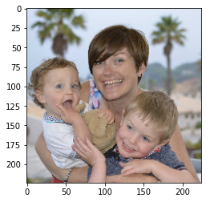

```python
# Original Image
plt.imshow(X[400])
```

```python
# Pre-processing Test Image set
X_test_prcsd=np.zeros((X_test.shape[0],224,224,3),dtype=np.float32)
for i in range(len(X_test)):
    X_test_prcsd[i]=preprocess_input(np.array(X_test[i].reshape(224,224,3)))
```

```
Clipping input data to the valid range for imshow with RGB data ([0..1] for floats or [0..255] for integers).
```

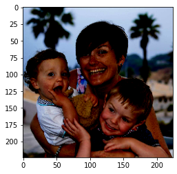

```python
# Pre-processed Test Image
plt.imshow(X_test_prcsd[0])
```

Show original mask for test image

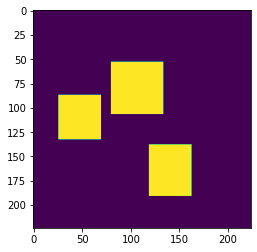

```python
# Original Mask
plt.imshow(y_test[0].reshape(224,224))
```

Predict the mask on the test image

```python
y_test_pred=model.predict(X_test_prcsd)
```

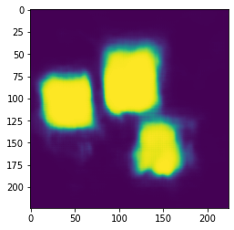

```python
plt.imshow(y_test_pred[0].reshape(224,224))
```

```python
# Dice coefficient for this test image
print(dice_coefficient(y_test[0],y_test_pred[0]))
```

```
tf.Tensor(0.71369946, shape=(), dtype=float32)
```

### Impose the mask on the test image (2 marks)

- In imshow use the alpha parameter and set it to greater than 0.5

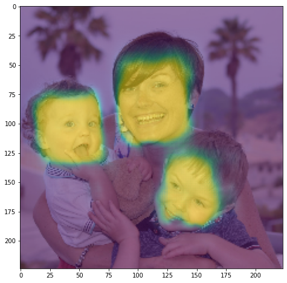

```python
plt.figure(figsize=(8,8))
plt.imshow(y_test_pred[0].reshape(224,224))
plt.imshow(X_test[0].reshape(224,224,3),alpha=0.5)
```

### Conclusion:

1. Project is done using MobileNet model by applying Transfer learning.
2. U-Net Architecture is built on top of mobilenet.
3. Applied ImageDataGenerator as we have less training data.
4. Performance of the model on test data seems to be satisfactory. However it can be further improved by having more training data.